# BACE: Bayesian Phylogenetic and Correlated Trait Imputation

Author

Shinichi Nakagawa, Szymek Drobniak, Daniel Noble

Published

February 12, 2026

# 1 Introduction

We provide a brief introduction to the *BACE* package for Bayesian phylogenetic and correlated trait imputation. The *BACE* package allows users to impute missing data in comparative datasets using Bayesian methods that account for phylogenetic relationships among species.

# 2 Installation

You can install the *BACE* package from GitHub using the following command:

```r
# Install from github and load
#install.packages("pacman")
  pacman::p_load(devtools)
devtools::install_github("daniel1noble/BACE")
  pacman::p_load(BACE, ape, phytools, MCMCglmm, dplyr, magrittr)
```

If you encounter any issues during installation, please ensure that you have the required dependencies installed.

# 3 Documentation

The main function in the *BACE* package is `bace_imp()`, which performs Bayesian imputation using chained equations. You can access the documentation for this function using the following command:

```r
?bace_imp
```

As you will see, the function allows you to specify fixed effects, random effects, phylogenetic tree, and other parameters for the imputation process. At the bare minimum, you need to provide a formula for the fixed effects, a formula for the random effects (including phylogeny), a phylogenetic tree, and the dataset with missing values.

# 4 Example Usage

## 4.1 Simulating Data

We’ll first simulate a dataset with missing values and a phylogenetic tree. We can do this using the `sim_bace()` function.

```r
# Set seed for reproducibility
set.seed(123)

# Simulate data. Note that threshold4 indicates an ordinal variable with 4 levels, and multinomial3 indicates a categorical variable with 3 levels. You can replace the numbers
sim_data <- sim_bace(response_type = "poisson",
                   predictor_types = c("gaussian", "binary", "threshold4", "multinomial3"),
                      phylo_signal = c(0.55, 0.75, 0.8, 0.7, 0.7),
                       missingness = c(0.2, 0.3, 0.4, 0.2, 0.5),
                           n_cases = 100,
                         n_species = 100)
```

```
Generated default beta_matrix with pre-set sparsity
```

```
Generated default beta_resp: -0.043, 0.457, -0.047, 0.178
```

We can then view the simulated data and phylogenetic tree because the `sim_bace()` function returns a list containing both objects. It also has a lot of other useful information about the simulation users can explore.

```r
# Object contains both the simulated data and phylogeny
    data <- sim_data$data
    tree <- sim_data$tree

# View first few rows of the data
    head(data)
```

```
  species  y        x1   x2   x3   x4
1   pJUhd  1        NA <NA>    2    A
2   h62z2  0        NA <NA> <NA>    B
3   69Haj  0 -3.045276 <NA>    2    B
4   gv77g 10        NA <NA>    3 <NA>
5   Arhl9 13 -1.785486 <NA>    4 <NA>
6   wLS5r  2        NA    1    2    C
```

Here, we can see that the dataset contains lots of missing values across different variable types. Of course, with normal modelling, we would need to exclude these cases to use a complete dataset. However, with *BACE* we simply feed in the entire dataset, specify the models we want to use for imputation (or the real model of interest), and impute the missing data.

## 4.2 Using *BACE* for Imputation

Now that we have the data and the phylogenetic tree we can use the `bace_imp()` function to impute the missing data.

**Caution**

It’s very important to ensure that all variables are correctly classified in the dataset (e.g., factors for categorical variables, numeric for continuous variables, etc.) before running the imputation. *BACE* will fit different models for different variable types, and so, if they have not been correctly classified you will be modeling the variable incorrectly.

If you want to see what *BACE* has classified each variable as, you can use the extract the types using the following command:

```r
bace_types <- bace_impute$types
```

Importantly, users also need to think carefully about the distributions of the variables themselves and transform them if necessary prior to running `bace_imp` (e.g., log-transforming skewed continuous variables).

There are two ways you can use `bace_imp`. The first is to specify a list of all the formulas for each variable you would like to fit. It is important here that, if you provide a list, that any variable with missing data is found as a response variable. This must be the case because *BACE* will not automatically build models for other variables if you provide a list of formulas (but see below). For example, we can run *BACE* as follows. Note that we specify a formula for each variable in the dataset that has missing data.

```r
# First check that all variables are correctly classified. If using sim_bace() this is done automatically, but always worth checking.
  str(data)

# Perform BACE imputation. Here we specify models for each variable in the dataset.
bace_impute <- bace_imp(fixformula = list("y ~ x1 + x2",
                                          "x1 ~ x2",
                                          "x2 ~ x4",
                                          "x3 ~ x1 + x2",
                                          "x4 ~ x1 + x2"),
                    ran_phylo_form = "~ 1 |species",
                             phylo = tree,
                              data = data,
                              runs = 5, verbose = FALSE)
```

What *BACE* will do here is fit a `MCMCglmm` model for each of the response variables specified in the formula list. At the first iteration, it will fill in missing values for any predictors using either their mean (for continuous variables) or randomly sampled values (for categorical variables). Models will then be fit using this complete predictor set and predictions will be made for missing values of the response variable. In the next run, those predictions will be used to ‘fill’ in missing values in any predictors instead. This cycle will continue until the predicted values converge. This process is repeated for the number of iterations specified by the `runs` argument. All the models will include the phylogenetic random effect specified in the `ran_phylo_form` argument.

```r
# Fit BACE with a single formula
bace_impute2 <- bace_imp(fixformula = "y ~ x1 + x2",
                     ran_phylo_form = "~ 1 |species",
                              phylo = tree,
                               data = data,
                               runs = 5, nitt = 20000, burnin = 5000, thin = 10)
```

```
Run 1, Imputed variable: y
Run 1, Imputed variable: x1
Run 1, Imputed variable: x2
Run 2, Imputed variable: y
Run 2, Imputed variable: x1
Run 2, Imputed variable: x2
Run 3, Imputed variable: y
Run 3, Imputed variable: x1
Run 3, Imputed variable: x2
Run 4, Imputed variable: y
Run 4, Imputed variable: x1
Run 4, Imputed variable: x2
Run 5, Imputed variable: y
Run 5, Imputed variable: x1
Run 5, Imputed variable: x2

========================================
BACE MCMC Diagnostics Summary
========================================

Number of models: 3
Total parameters: 15
  Fixed effects: 9
  Variance components: 6
  Fixed units (threshold/categorical): 1

Mean Effective Sample Size:
  Fixed effects:      961.4
  Variance components: 316.8

Convergence Assessment:
  Acceptable  :   1 parameters (6.7%)
  Check       :   6 parameters (40.0%)
  Fixed       :   1 parameters (6.7%)
  Good        :   7 parameters (46.7%)

Overall: CHECK - Many parameters show convergence issues
  Consider increasing nitt, adjusting priors, or checking model specification

Convergence by Response Variable:
----------------------------------------
[CH] y              :  1/ 5 parameters good
    Check convergence: x1, x2.L, species, units
[OK] x1             :  4/ 5 parameters good
[CH] x2             :  2/ 4 parameters good (1 fixed)
    Check convergence: y, species
========================================
```

As you can see from the printout above, *BACE* provides a summary of the imputation process, including the number of models fitted, parameters estimated, and effective sample sizes which evaluate how well the MCMC chains for parameters are mixing. This is important to check to ensure that the imputation is performing well.

## 4.3 Evaluating Final Models

*BACE* returns a list of models for each variable that was imputed. You can access these models and evaluate them as you would any `MCMCglmm` model. This is important for checking model fit and convergence along with downstream inference. For example, you can check the summary of the model for the response variable `y` as follows:

```r
# Access the model for the response variable 'y'
model_y <- bace_impute2$models[["y"]]

# View summary of the model
summary(model_y)
```

```
 Iterations = 5001:19991
 Thinning interval  = 10
 Sample size  = 1500

 DIC: 206.4653

 G-structure:  ~species

        post.mean  l-95% CI u-95% CI eff.samp
species    0.7143 0.0006709     2.23    36.67

 R-structure:  ~units

      post.mean l-95% CI u-95% CI eff.samp
units    0.6858   0.2041    1.152    34.47

 Location effects: y ~ x1 + x2

            post.mean l-95% CI u-95% CI eff.samp  pMCMC
(Intercept)  -0.02146 -0.84288  0.76609   1217.6 0.9387
x1           -0.06911 -0.22342  0.08340    329.5 0.3800
x2.L          0.28617 -0.03963  0.60954    246.8 0.0867 .
---
Signif. codes:  0 '***' 0.001 '**' 0.01 '*' 0.05 '.' 0.1 ' ' 1
```

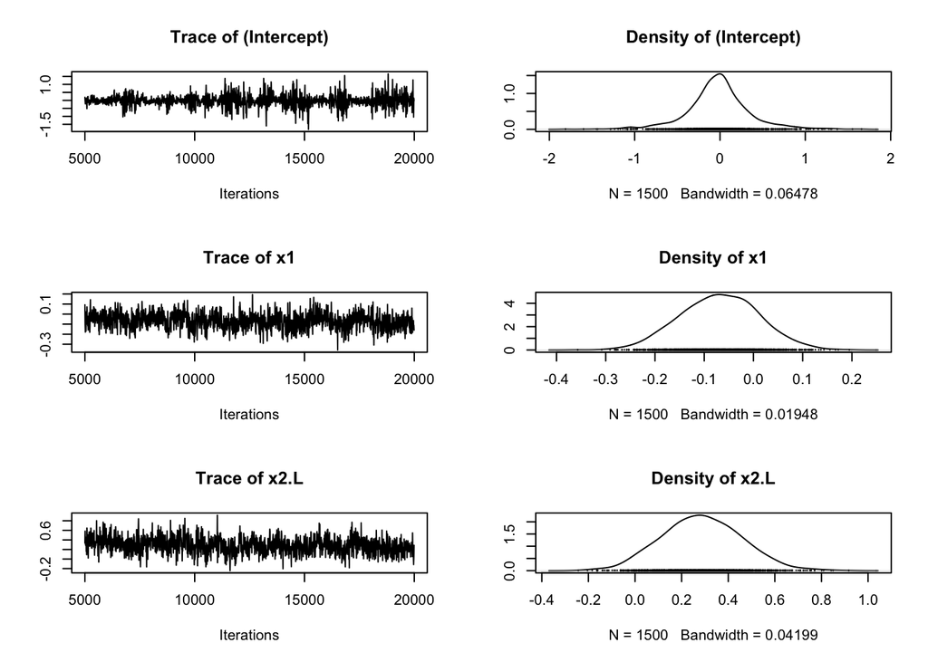

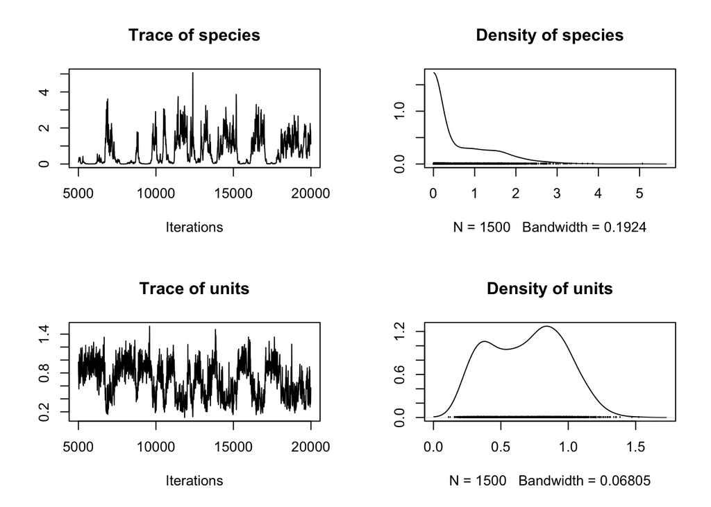

```r
# Plot trace and density plots for model parameters
plot(model_y)
```

We can see here that the phylogenetic variance estimate (i.e., `species` random effect) is mixing poorly. We should go back and re-run the imputation with more iterations or possibly adjust our prior to ensure better mixing for this parameter.

# 5 Phylogenetic and Non-Phylogenetic Random Effects

BACE allows users to include both phylogenetic and non-phylogenetic random effects in the imputation models. This is important if multiple replicates of species are included in the dataset (e.g., multiple populations of the same species). In this case, users can specify a non-phylogenetic random effect for species identity in addition to the phylogenetic random effect. This is done by adjusting the `species = FALSE` argument in `bacse_imp`, setting it to TRUE.

```r
# Simulate data with multiple replicates per species
set.seed(123)
sim_data2 <- sim_bace(response_type = "poisson",
                   predictor_types = c("gaussian", "binary", "threshold4", "multinomial3"),
                      phylo_signal = c(0.55, 0.75, 0.8, 0.7, 0.7),
                       missingness = c(0.2, 0.3, 0.4, 0.2, 0.5),
                                rr = TRUE,
                           n_cases = 100,
                         n_species = 20,
                           rr_form = list(species = c("x1")))

# Object contains both the simulated data and phylogeny
    data2 <- sim_data2$data
    tree2 <- sim_data2$tree

# View first few rows of the data
    head(data2)
```

```
  species  y         x1   x2   x3   x4
1   P9vI3  6 -0.7731097    1    4    C
2   eJBm5 NA         NA    1 <NA> <NA>
3   P9vI3  1         NA <NA>    4    C
4   JE8PP  1 -2.9886121    0 <NA> <NA>
5   eJBm5  1         NA    1    3 <NA>
6   sA8eL 12         NA <NA>    2 <NA>
```

```r
# We can also make a table of the number of cases per species to confirm that there are multiple replicates per species
    dim(data2)
```

```
[1] 100   6
```

```r
    length(unique(data2$species))
```

```
[1] 20
```

We now have a dataset with 100 cases but only 20 species, meaning that there are multiple replicates per species. We can run *BACE* on this dataset while including a non-phylogenetic random effect for species identity as follows:

```r
bace_impute3 <- bace_imp(fixformula = "y ~ x1 + x2",
                     ran_phylo_form = "~ 1 |species",
                              phylo = tree2,
                               data = data2,
                               runs = 5, nitt = 20000, burnin = 5000, thin = 10, species = TRUE)
```

```
Species effect decomposition enabled: 20 out of 20 species (100%) have replicated observations.
```

```
Run 1, Imputed variable: y
Run 1, Imputed variable: x1
Run 1, Imputed variable: x2
Run 2, Imputed variable: y
Run 2, Imputed variable: x1
Run 2, Imputed variable: x2
Run 3, Imputed variable: y
Run 3, Imputed variable: x1
Run 3, Imputed variable: x2
Run 4, Imputed variable: y
Run 4, Imputed variable: x1
Run 4, Imputed variable: x2
Run 5, Imputed variable: y
Run 5, Imputed variable: x1
Run 5, Imputed variable: x2

========================================
BACE MCMC Diagnostics Summary
========================================

Number of models: 3
Total parameters: 18
  Fixed effects: 9
  Variance components: 9
  Fixed units (threshold/categorical): 1

Mean Effective Sample Size:
  Fixed effects:      938.4
  Variance components: 430.0

Convergence Assessment:
  Check       :   8 parameters (44.4%)
  Fixed       :   1 parameters (5.6%)
  Good        :   9 parameters (50.0%)

Overall: CHECK - Many parameters show convergence issues
  Consider increasing nitt, adjusting priors, or checking model specification

Convergence by Response Variable:
----------------------------------------
[OK] y              :  5/ 6 parameters good
    Check convergence: species
[CH] x1             :  4/ 6 parameters good
    Check convergence: species, species2
[CH] x2             :  0/ 5 parameters good (1 fixed)
    Check convergence: (Intercept), x1, y, species, species2
========================================
```

```r
# We can view the final model for y to check that both random effects are included
model_y2 <- bace_impute3$models[["y"]]
summary(model_y2)
```

```
 Iterations = 5001:19991
 Thinning interval  = 10
 Sample size  = 1500

 DIC: 201.2756

 G-structure:  ~species

        post.mean  l-95% CI u-95% CI eff.samp
species     0.433 0.0001999    1.896      144

               ~species2

         post.mean  l-95% CI u-95% CI eff.samp
species2    0.4094 0.0004199   0.9779    248.5

 R-structure:  ~units

      post.mean l-95% CI u-95% CI eff.samp
units    0.5918   0.4049   0.8516     1282

 Location effects: y ~ x1 + x2

            post.mean l-95% CI u-95% CI eff.samp  pMCMC
(Intercept)  -0.28377 -1.07324  0.58138     1372 0.3987
x1           -0.03534 -0.21281  0.13330     1500 0.6560
x2.L          0.63330  0.02089  1.19010     1500 0.0307 *
---
Signif. codes:  0 '***' 0.001 '**' 0.01 '*' 0.05 '.' 0.1 ' ' 1
```

```r
bace_impute4 <- bace_imp(fixformula = "y ~ x1 + x2",
                     ran_phylo_form = "~ 1 |species",
                              phylo = tree2,
                               data = data2,
                               runs = 5, nitt = 20000, burnin = 5000, thin = 10, species = TRUE)
```

```
Run 1, Imputed variable: y
Run 1, Imputed variable: x1
Run 1, Imputed variable: x2
Run 2, Imputed variable: y
Run 2, Imputed variable: x1
Run 2, Imputed variable: x2
Run 3, Imputed variable: y
Run 3, Imputed variable: x1
Run 3, Imputed variable: x2
Run 4, Imputed variable: y
Run 4, Imputed variable: x1
Run 4, Imputed variable: x2
Run 5, Imputed variable: y
Run 5, Imputed variable: x1
Run 5, Imputed variable: x2

========================================
BACE MCMC Diagnostics Summary
========================================

Number of models: 3
Total parameters: 18
  Fixed effects: 9
  Variance components: 9
  Fixed units (threshold/categorical): 1

Mean Effective Sample Size:
  Fixed effects:      961.9
  Variance components: 451.3

Convergence Assessment:
  Check       :   8 parameters (44.4%)
  Fixed       :   1 parameters (5.6%)
  Good        :   9 parameters (50.0%)

Overall: CHECK - Many parameters show convergence issues
  Consider increasing nitt, adjusting priors, or checking model specification

Convergence by Response Variable:
----------------------------------------
[OK] y              :  5/ 6 parameters good
    Check convergence: species
[CH] x1             :  4/ 6 parameters good
    Check convergence: species, species2
[CH] x2             :  0/ 5 parameters good (1 fixed)
    Check convergence: (Intercept), x1, y, species, species2
========================================
```

## 5.1 Adjusting MCMC Parameters For Convergence

As we can see from the model summary above, some parameters may have low effective sample sizes (ESS) which indicates poor mixing of the MCMC chains. This can be a sign that the imputation is not performing well and that more iterations are needed to achieve convergence. Lets have a look:

```r
model_x1 <- bace_impute3$models[["x1"]]
summary(model_x1)
```

```
 Iterations = 5001:19991
 Thinning interval  = 10
 Sample size  = 1500

 DIC: 89.34682

 G-structure:  ~species

        post.mean  l-95% CI u-95% CI eff.samp
species     1.421 0.0003159    4.847    92.89

               ~species2

         post.mean l-95% CI u-95% CI eff.samp
species2     0.899 0.000352    2.063    108.9

 R-structure:  ~units

      post.mean l-95% CI u-95% CI eff.samp
units    0.1583  0.09962   0.2202     1500

 Location effects: x1 ~ y + x2

            post.mean  l-95% CI  u-95% CI eff.samp pMCMC
(Intercept) -0.099841 -1.666273  1.129876     1106 0.993
y            0.009412 -0.021993  0.038632     1500 0.540
x2.L        -0.187046 -0.488638  0.159382     1326 0.264
```

```r
model_x2 <- bace_impute3$models[["x2"]]
summary(model_x2)
```

```
 Iterations = 5001:19991
 Thinning interval  = 10
 Sample size  = 1500

 DIC: 11.4237

 G-structure:  ~species

        post.mean l-95% CI u-95% CI eff.samp
species     225.1 0.000339    626.5    49.53

               ~species2

         post.mean  l-95% CI u-95% CI eff.samp
species2     80.38 0.0004792      329    13.91

 R-structure:  ~units

      post.mean l-95% CI u-95% CI eff.samp
units         1        1        1        0

 Location effects: x2 ~ x1 + y

            post.mean l-95% CI u-95% CI eff.samp  pMCMC
(Intercept)    7.8610 -10.2228  26.6525   79.131 0.3400
x1            -3.3436  -6.7864  -0.3788   57.443 0.0253 *
y              3.3022   1.3582   5.5662    5.484 <7e-04 ***
---
Signif. codes:  0 '***' 0.001 '**' 0.01 '*' 0.05 '.' 0.1 ' ' 1
```

As we can see x1 and x2 models have poor mixing and low ESS for some parameters. Obviously, depending on the model complexity and data size etc, some models will need longer runtimes. This is likely because the imputation process has not yet converged. To address this, we can increase the number of iterations (i.e., `nitt`), increase the burn-in period (i.e., `burnin`), and/or adjust the thinning interval (i.e., `thin`) to improve mixing and convergence of the MCMC chains.

Users can adjust the MCMC parameters (i.e., `nitt`, `thin`, and `burnin`) for each model by providing a list of values for each parameter that corresponds to the order of the formulas provided in the `fixformula` argument. For example, if you have 5 formulas in your `fixformula` list, you can provide a list of 5 values for each MCMC parameter as follows:

```r
# Define MCMC parameters for each model
  nitt_list <- list(60000, 60000, 105000)
  thin_list <- list(10, 10, 10)

# Run BACE with model-specific MCMC parameters
bace_impute5 <- bace_imp(fixformula = "y ~ x1 + x2",
                    ran_phylo_form = "~ 1 |species",
                             phylo = tree2,
                              data = data2,
                              runs = 5, nitt = nitt_list, thin = thin_list, burnin = 5000, species = TRUE)
```

```
Run 1, Imputed variable: y
Run 1, Imputed variable: x1
Run 1, Imputed variable: x2
Run 2, Imputed variable: y
Run 2, Imputed variable: x1
Run 2, Imputed variable: x2
Run 3, Imputed variable: y
Run 3, Imputed variable: x1
Run 3, Imputed variable: x2
Run 4, Imputed variable: y
Run 4, Imputed variable: x1
Run 4, Imputed variable: x2
Run 5, Imputed variable: y
Run 5, Imputed variable: x1
Run 5, Imputed variable: x2

========================================
BACE MCMC Diagnostics Summary
========================================

Number of models: 3
Total parameters: 18
  Fixed effects: 9
  Variance components: 9
  Fixed units (threshold/categorical): 1

Mean Effective Sample Size:
  Fixed effects:      3201.9
  Variance components: 1566.4

Convergence Assessment:
  Acceptable  :   1 parameters (5.6%)
  Check       :  11 parameters (61.1%)
  Fixed       :   1 parameters (5.6%)
  Good        :   5 parameters (27.8%)

Overall: CHECK - Many parameters show convergence issues
  Consider increasing nitt, adjusting priors, or checking model specification

Convergence by Response Variable:
----------------------------------------
[CH] y              :  2/ 6 parameters good
    Check convergence: (Intercept), x1, species, species2
[CH] x1             :  3/ 6 parameters good
    Check convergence: (Intercept), species2
[CH] x2             :  0/ 5 parameters good (1 fixed)
    Check convergence: (Intercept), x1, y, species, species2
========================================
```

As you can imagine, longer runtimes will mean that `bace_imp` will need to take longer. The diagnostics still suggest possible issues with mixing for some parameters, so we may need to further increase the number of iterations or adjust the priors to improve mixing, however, it’s still good to look at the final models to check the model visually.

## 5.2 Assessing Model Convergence

We need to check whether the numbers of runs we’ve done has lead to convergence of the imputation process. We can do this by looking at the trace and density plots for the parameters in the models. For example, we can check the model for `y` as follows:

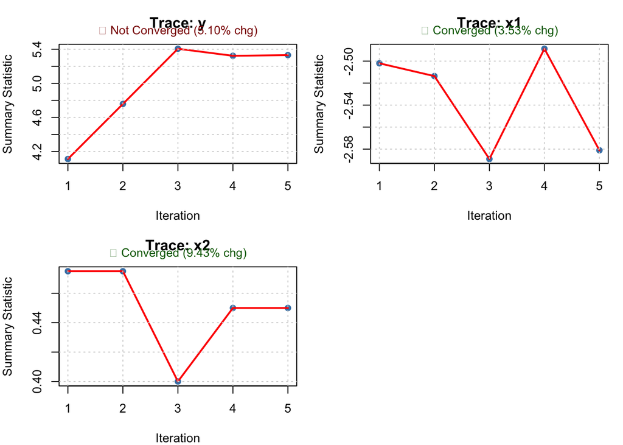

```r
# Assess whether number of runs was enough by looking at the stability of imputed points across runs. Adjust runs if needed
converge <- assess_convergence(bace_impute2, method = "summary")
plot(converge)
```

```r
# Now that we know that we can run BACE longer

# Fit BACE with a single formula
bace_impute2_2 <- bace_imp(fixformula = "y ~ x1 + x2",
                     ran_phylo_form = "~ 1 |species",
                              phylo = tree,
                               data = data,
                               runs = 15, nitt = 100000, burnin = 10000, thin = 10)
```

```
Run 1, Imputed variable: y
Run 1, Imputed variable: x1
Run 1, Imputed variable: x2
Run 2, Imputed variable: y
Run 2, Imputed variable: x1
Run 2, Imputed variable: x2
Run 3, Imputed variable: y
Run 3, Imputed variable: x1
Run 3, Imputed variable: x2
Run 4, Imputed variable: y
Run 4, Imputed variable: x1
Run 4, Imputed variable: x2
Run 5, Imputed variable: y
Run 5, Imputed variable: x1
Run 5, Imputed variable: x2
Run 6, Imputed variable: y
Run 6, Imputed variable: x1
Run 6, Imputed variable: x2
Run 7, Imputed variable: y
Run 7, Imputed variable: x1
Run 7, Imputed variable: x2
Run 8, Imputed variable: y
Run 8, Imputed variable: x1
Run 8, Imputed variable: x2
Run 9, Imputed variable: y
Run 9, Imputed variable: x1
Run 9, Imputed variable: x2
Run 10, Imputed variable: y
Run 10, Imputed variable: x1
Run 10, Imputed variable: x2
Run 11, Imputed variable: y
Run 11, Imputed variable: x1
Run 11, Imputed variable: x2
Run 12, Imputed variable: y
Run 12, Imputed variable: x1
Run 12, Imputed variable: x2
Run 13, Imputed variable: y
Run 13, Imputed variable: x1
Run 13, Imputed variable: x2
Run 14, Imputed variable: y
```

[output cut: 23 more lines]

```
  Fixed       :   1 parameters (6.7%)
  Good        :   9 parameters (60.0%)

Overall: CHECK - Many parameters show convergence issues
  Consider increasing nitt, adjusting priors, or checking model specification

Convergence by Response Variable:
----------------------------------------
[CH] y              :  3/ 5 parameters good
    Check convergence: species, units
[OK] x1             :  4/ 5 parameters good
    Check convergence: species
[~] x2             :  2/ 4 parameters good (1 fixed)
    Check convergence: y
========================================
```

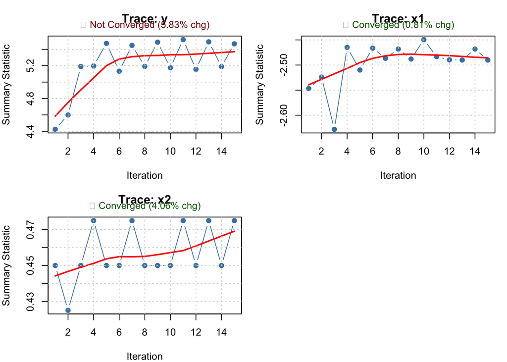

```r
# Check again for convergence
converge <- assess_convergence(bace_impute2_2, method = "summary")
plot(converge)
```

## 5.3 Simple BACE Workflow

Now that you are aware of the different components of the *BACE* workflow, you can put it all together in a simple workflow. This will involve simulating data, running the imputation, checking model fit and convergence, and then rerunning the model say, 10 times, and simply pooling the results to account for imputation uncertainty.

```
=======================================================
BACE: Bayesian Analysis with Chained Equations
=======================================================

Step 1: Initial imputation for convergence assessment
-------------------------------------------------------
```

```
Run 1, Imputed variable: y
Run 1, Imputed variable: x1
Run 1, Imputed variable: x2
Run 2, Imputed variable: y
Run 2, Imputed variable: x1
Run 2, Imputed variable: x2
Run 3, Imputed variable: y
Run 3, Imputed variable: x1
Run 3, Imputed variable: x2
Run 4, Imputed variable: y
Run 4, Imputed variable: x1
Run 4, Imputed variable: x2
Run 5, Imputed variable: y
Run 5, Imputed variable: x1
Run 5, Imputed variable: x2
Run 6, Imputed variable: y
Run 6, Imputed variable: x1
Run 6, Imputed variable: x2
Run 7, Imputed variable: y
Run 7, Imputed variable: x1
Run 7, Imputed variable: x2
Run 8, Imputed variable: y
Run 8, Imputed variable: x1
Run 8, Imputed variable: x2
Run 9, Imputed variable: y
Run 9, Imputed variable: x1
Run 9, Imputed variable: x2
Run 10, Imputed variable: y
Run 10, Imputed variable: x1
Run 10, Imputed variable: x2
Run 11, Imputed variable: y
Run 11, Imputed variable: x1
Run 11, Imputed variable: x2
Run 12, Imputed variable: y
Run 12, Imputed variable: x1
Run 12, Imputed variable: x2
Run 13, Imputed variable: y
Run 13, Imputed variable: x1
Run 13, Imputed variable: x2
Run 14, Imputed variable: y
```

[output cut: 27 more lines]

```
  Consider increasing nitt, adjusting priors, or checking model specification

Convergence by Response Variable:
----------------------------------------
[OK] y              :  5/ 6 parameters good
[CH] x1             :  3/ 6 parameters good
    Check convergence: (Intercept), species2
[CH] x2             :  0/ 5 parameters good (1 fixed)
    Check convergence: (Intercept), x1, y, species, species2
========================================



Step 2: Convergence assessment
-------------------------------------------------------
```

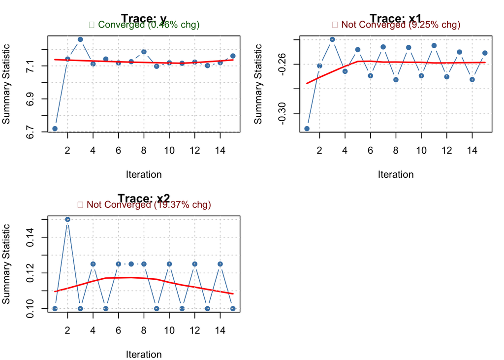

```
Convergence not achieved. Running additional iterations...
Attempt 2 of 3
-------------------------------------------------------
```

```
Run 1, Imputed variable: y
Run 1, Imputed variable: x1
Run 1, Imputed variable: x2
Run 2, Imputed variable: y
Run 2, Imputed variable: x1
Run 2, Imputed variable: x2
Run 3, Imputed variable: y
Run 3, Imputed variable: x1
Run 3, Imputed variable: x2
Run 4, Imputed variable: y
Run 4, Imputed variable: x1
Run 4, Imputed variable: x2
Run 5, Imputed variable: y
Run 5, Imputed variable: x1
Run 5, Imputed variable: x2
Run 6, Imputed variable: y
Run 6, Imputed variable: x1
Run 6, Imputed variable: x2
Run 7, Imputed variable: y
Run 7, Imputed variable: x1
Run 7, Imputed variable: x2
Run 8, Imputed variable: y
Run 8, Imputed variable: x1
Run 8, Imputed variable: x2
Run 9, Imputed variable: y
Run 9, Imputed variable: x1
Run 9, Imputed variable: x2
Run 10, Imputed variable: y
Run 10, Imputed variable: x1
Run 10, Imputed variable: x2
Run 11, Imputed variable: y
Run 11, Imputed variable: x1
Run 11, Imputed variable: x2
Run 12, Imputed variable: y
Run 12, Imputed variable: x1
Run 12, Imputed variable: x2
Run 13, Imputed variable: y
Run 13, Imputed variable: x1
Run 13, Imputed variable: x2
Run 14, Imputed variable: y
```

[output cut: 44 more lines]

```
  Fixed       :   1 parameters (5.6%)
  Good        :   7 parameters (38.9%)

Overall: CHECK - Many parameters show convergence issues
  Consider increasing nitt, adjusting priors, or checking model specification

Convergence by Response Variable:
----------------------------------------
[~] y              :  4/ 6 parameters good
    Check convergence: (Intercept)
[~] x1             :  3/ 6 parameters good
    Check convergence: units
[CH] x2             :  0/ 5 parameters good (1 fixed)
    Check convergence: (Intercept), x1, y, species, species2
========================================
```

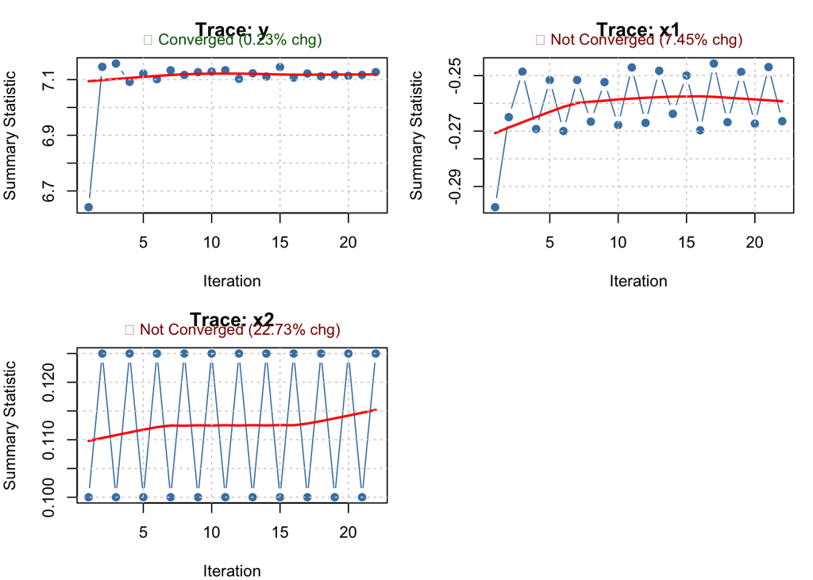

```
Convergence not achieved. Running additional iterations...
Attempt 3 of 3
-------------------------------------------------------
```

```
Run 1, Imputed variable: y
Run 1, Imputed variable: x1
Run 1, Imputed variable: x2
Run 2, Imputed variable: y
Run 2, Imputed variable: x1
Run 2, Imputed variable: x2
Run 3, Imputed variable: y
Run 3, Imputed variable: x1
Run 3, Imputed variable: x2
Run 4, Imputed variable: y
Run 4, Imputed variable: x1
Run 4, Imputed variable: x2
Run 5, Imputed variable: y
Run 5, Imputed variable: x1
Run 5, Imputed variable: x2
Run 6, Imputed variable: y
Run 6, Imputed variable: x1
Run 6, Imputed variable: x2
Run 7, Imputed variable: y
Run 7, Imputed variable: x1
Run 7, Imputed variable: x2
Run 8, Imputed variable: y
Run 8, Imputed variable: x1
Run 8, Imputed variable: x2
Run 9, Imputed variable: y
Run 9, Imputed variable: x1
Run 9, Imputed variable: x2
Run 10, Imputed variable: y
Run 10, Imputed variable: x1
Run 10, Imputed variable: x2
Run 11, Imputed variable: y
Run 11, Imputed variable: x1
Run 11, Imputed variable: x2
Run 12, Imputed variable: y
Run 12, Imputed variable: x1
Run 12, Imputed variable: x2
Run 13, Imputed variable: y
Run 13, Imputed variable: x1
Run 13, Imputed variable: x2
Run 14, Imputed variable: y
```

[output cut: 79 more lines]

```
  Check       :   8 parameters (44.4%)
  Fixed       :   1 parameters (5.6%)
  Good        :   7 parameters (38.9%)

Overall: CHECK - Many parameters show convergence issues
  Consider increasing nitt, adjusting priors, or checking model specification

Convergence by Response Variable:
----------------------------------------
[CH] y              :  3/ 6 parameters good
    Check convergence: x2.L, species, species2
[~] x1             :  4/ 6 parameters good
[CH] x2             :  0/ 5 parameters good (1 fixed)
    Check convergence: (Intercept), x1, y, species, species2
========================================
```

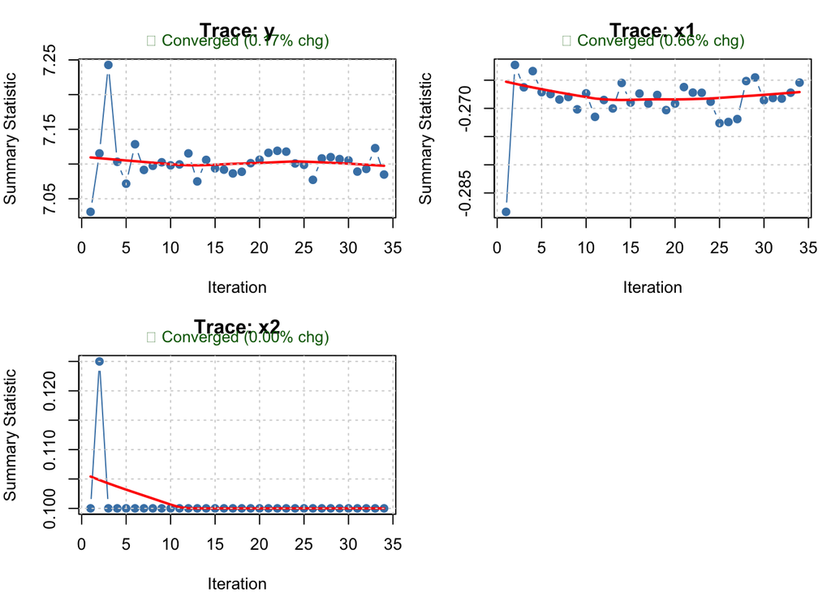

```
Step 3: Final imputation runs for posterior pooling
-------------------------------------------------------

=== Running 10 final imputation iterations ===

Run 1/10 - Imputed variable: y
Run 1/10 - Imputed variable: x1
Run 1/10 - Imputed variable: x2
Run 2/10 - Imputed variable: y
Run 2/10 - Imputed variable: x1
Run 2/10 - Imputed variable: x2

Completed 2/10 runs

Run 3/10 - Imputed variable: y
Run 3/10 - Imputed variable: x1
Run 3/10 - Imputed variable: x2
Run 4/10 - Imputed variable: y
Run 4/10 - Imputed variable: x1
Run 4/10 - Imputed variable: x2

Completed 4/10 runs

Run 5/10 - Imputed variable: y
Run 5/10 - Imputed variable: x1
Run 5/10 - Imputed variable: x2
Run 6/10 - Imputed variable: y
Run 6/10 - Imputed variable: x1
Run 6/10 - Imputed variable: x2

Completed 6/10 runs

Run 7/10 - Imputed variable: y
Run 7/10 - Imputed variable: x1
Run 7/10 - Imputed variable: x2
Run 8/10 - Imputed variable: y
Run 8/10 - Imputed variable: x1
Run 8/10 - Imputed variable: x2

Completed 8/10 runs
```

[output cut: 18 more lines]

```
Posterior pooling complete!
Pooled 3 variable model(s) across 10 imputations

=======================================================
BACE Analysis Complete!
=======================================================

Convergence achieved: TRUE
Number of attempts: 3
Final imputations: 10

Access results via:
  - $pooled_models: Pooled posterior distributions
  - $convergence: Convergence diagnostics
  - $final_results: Final imputation datasets and models
```

```r
# Run the full bace workflow:
bace_final <- bace(fixformula = "y ~ x1 + x2",
                     ran_phylo_form = "~ 1 |species",
                              phylo = tree2,
                               data = data2,
                               species = TRUE,
                               runs = 15, nitt = 100000, burnin = 10000, thin = 10, plot = TRUE)
```

```r
# Now have a look at the final models and the pooled results
y_model <- bace_final$pooled_models$models$y
summary(y_model)
```

```
+--------------------------------------------------------------+
|  BACE Pooled MCMCglmm Summary (Imputation Uncertainty Included)|
+--------------------------------------------------------------+

Pooled from 10 imputations
Total posterior samples: 90000
  (= 9000 samples/imputation x 10 imputations)

Note: Posterior summaries account for both estimation and imputation uncertainty.
--------------------------------------------------------------
```

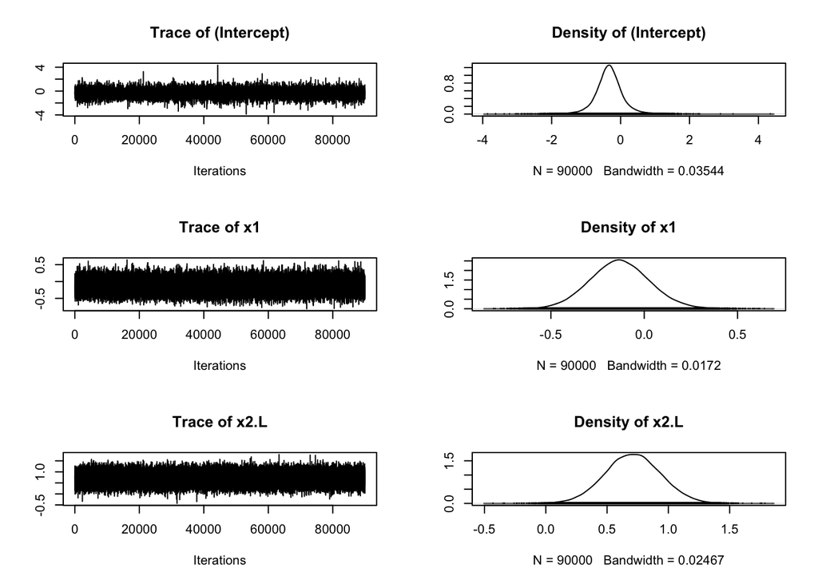

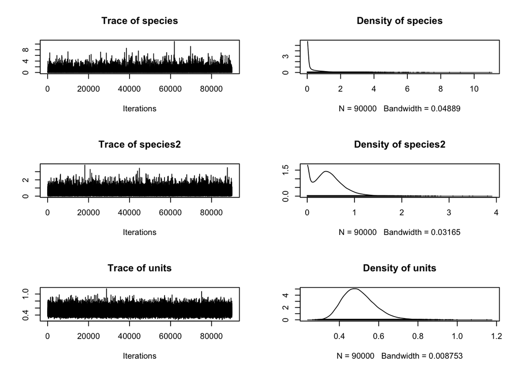

```r
plot(y_model)
```

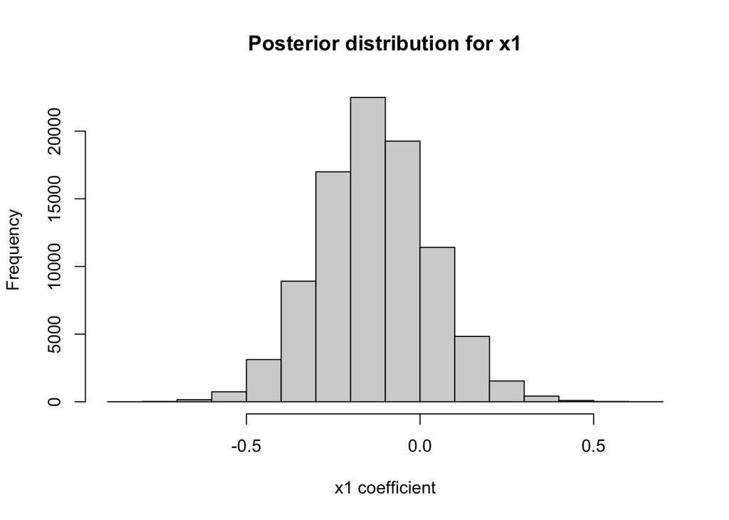

```r
# We can now extract posteriors in the same way we would use a normal MCMCglmm model, but now we have the pooled results that account for imputation uncertainty. For example, we can extract the posterior samples for the fixed effects as follows:

hist(y_model$Sol[, "x1"], main = "Posterior distribution for x1", xlab = "x1 coefficient")
```